# Trading and investment account summary

# For 2020-09-01

Summary text: The equity value of my live trading portfolio changed by 1.52 % (US$ 549.76 ) from US$ 36053.01 to US$ 36602.77 today ( 2020-09-01 ). The trading proceeds in my live account were US$ 50.0699999999997 . The book proceeds in my portfolio changed from US$ 2681.65 to US$ 3181.34

## Portfolio

The below table shows the current positions in the live account as well as their current and total performance. “book_proceed” indicates the unrealized profit in that position.

| symbol | close | closePerc | Total_Change_close | entry_price | position | position_size | entry_position | totalPerc | book_proceed | sector |
| --- | --- | --- | --- | --- | --- | --- | --- | --- | --- | --- |
| KWEB | 72.89 | 3.65 | 257 | 71.28 | 100 | 7289.00 | 7128.12 | 2.21 | 160.88 | Miscellaneous |
| BRK.B | 218.54 | 0.23 | 12.5 | 195.40 | 25 | 5463.50 | 4885.08 | 10.59 | 578.42 | Finance |
| SEAS | 20.43 | 0.2 | -7.2 | 19.05 | -180 | -3677.40 | -3429.01 | -6.75 | -248.39 | Consumer Services |
| CAKE | 30.75 | 4.2 | 124 | 24.53 | 100 | 3075.00 | 2452.55 | 20.24 | 622.45 | Consumer Services |
| SQ | 166.67 | 4.51 | 108 | 143.24 | 15 | 2500.05 | 2148.55 | 14.06 | 351.5 | Technology Services |
| TSLA | 2375.20 | -4.71 | -117.35 | 1405.56 | 1 | 2375.20 | 1405.56 | 40.82 | 969.64 | Consumer Durables |
| EZA | 38.36 | 3.17 | -64.9 | 38.54 | -55 | -2109.80 | -2119.70 | 0.47 | 9.9 | Miscellaneous |
| INDA | 34.02 | 2.07 | 41.4 | 33.10 | 60 | 2041.20 | 1985.99 | 2.7 | 55.21 | Miscellaneous |
| GOOG | 1660.71 | 1.76 | 28.68 | 1599.21 | 1 | 1660.71 | 1599.21 | 3.7 | 61.5 | Technology Services |
| MIK | 11.50 | 2.4 | 33.75 | 9.01 | 125 | 1437.50 | 1126.01 | 21.67 | 311.49 | Retail Trade |
| SLV | 26.16 | -0.27 | -3.5 | 22.90 | 50 | 1308.00 | 1144.95 | 12.47 | 163.05 | Miscellaneous |
| TPR | 14.75 | 0.14 | 1.7 | 14.96 | 85 | 1253.75 | 1271.99 | -1.45 | -18.24 | Retail Trade |
| MGM | 22.77 | 1.2 | 12.15 | 21.88 | 45 | 1024.65 | 984.75 | 3.89 | 39.9 | Consumer Services |
| ABT | 106.55 | -2.64 | -26.01 | 109.71 | 9 | 958.95 | 987.41 | -2.97 | -28.46 | Health Technology |
| IAU | 18.80 | 0.08 | 0.75 | 18.96 | 50 | 940.00 | 947.84 | -0.83 | -7.84 | Miscellaneous |
| UNM | 18.54 | 0.43 | 4 | 19.21 | 50 | 927.00 | 960.30 | -3.59 | -33.3 | Finance |
| GOLD | 29.33 | -1.05 | -9.3 | 28.23 | 30 | 879.90 | 847.01 | 3.74 | 32.89 | Non-Energy Minerals |
| RVLV | 21.48 | 6.97 | 53.2 | 18.07 | 38 | 816.24 | 686.53 | 15.89 | 129.71 | Retail Trade |
| SWKS | 146.47 | 1.13 | 8.15 | 131.85 | 5 | 732.35 | 659.25 | 9.98 | 73.1 | Electronic Technology |
| CAT | 146.06 | 2.64 | 18.8 | 142.04 | 5 | 730.30 | 710.20 | 2.75 | 20.1 | Producer Manufacturing |
| PPLT | 88.95 | 1.23 | 8.68 | 89.44 | 8 | 711.64 | 715.49 | -0.54 | -3.85 | Miscellaneous |
| EPHE | 26.39 | -0.64 | 4.25 | 25.67 | -25 | -659.75 | -641.70 | -2.74 | -18.05 | Miscellaneous |
| PALL | 213.80 | 0.92 | 5.82 | 219.68 | 3 | 641.40 | 659.04 | -2.75 | -17.64 | Miscellaneous |
| V | 213.38 | 0.65 | 4.14 | 194.66 | 3 | 640.14 | 583.99 | 8.77 | 56.15 | Finance |
| DBX | 21.31 | 0.66 | 4.2 | 20.73 | 30 | 639.30 | 621.75 | 2.75 | 17.55 | Technology Services |
| NFLX | 556.99 | 5.28 | 27.94 | 486.00 | 1 | 556.99 | 486.00 | 12.75 | 70.99 | Consumer Services |
| UPWK | 15.29 | 0.39 | 2.16 | 14.48 | 36 | 550.44 | 521.36 | 5.28 | 29.08 | Technology Services |
| LMND | 56.18 | -4.29 | -20.16 | 78.07 | 8 | 449.44 | 624.57 | -38.97 | -175.13 | Finance |
| CCL | 16.50 | 0.12 | 0.5 | 14.54 | 25 | 412.50 | 363.50 | 11.88 | 49 | Consumer Services |
| GDX | 41.68 | -1.37 | -4.64 | 43.89 | 8 | 333.44 | 351.14 | -5.31 | -17.7 | Miscellaneous |
| CRUS | 61.09 | 0.74 | 2.25 | 71.60 | 5 | 305.45 | 358.02 | -17.21 | -52.57 | Electronic Technology |

| symbol | close | closePerc | Total_Change_close | entry_price | position | position_size | entry_position | totalPerc | book_proceed | sector |
| --- | --- | --- | --- | --- | --- | --- | --- | --- | --- | --- |
| Summary | NA | NA | 510.96 | NA | 1181 | 47100.99 | NA | 6.75 | 3181.341 | NA |

[interactive chart not shown]

The performance of my live stock portfolio/trading account vs. my paper trading account and the benchmark ‘SPY’, the US large cap stock market index ETF in percent since June 09 2020.

[interactive chart not shown]

This plot shows a summary of the trading activity on that day. Above 0 is a gain, below is a loss. TRUE indicated live trading account, FALSE is paper trading. A buy side trade is a closed short sale trade and sell side trade is a closed long trade.

[interactive chart not shown]

My current portfolio sorted by sectors. The plot reads clock-wise. Positions below 0 are short positions. Clicking a slice of the pie chart directs to marketwatch.com for further information.

[interactive chart not shown]

These two plots indicate the composition of my portfolio and the change of it over the past week.

[interactive chart not shown]

The inner circle is Monday, the outer circle is Friday.

[interactive chart not shown]

The colors in this plot indicate the daily percentage change of each stock in my portfolio.

[interactive chart not shown]

I classified the stocks in my portfolio by sector. The area represents the size of the position in the portfolio. Long postions

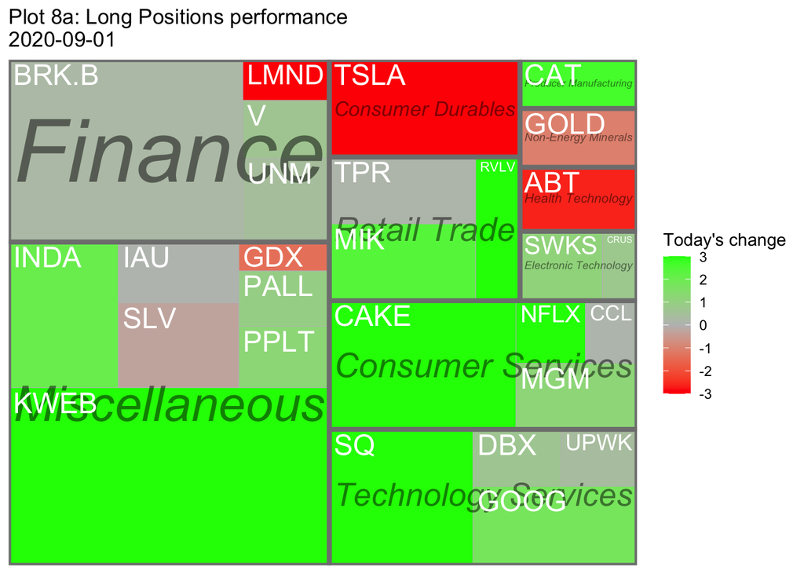

Short postions

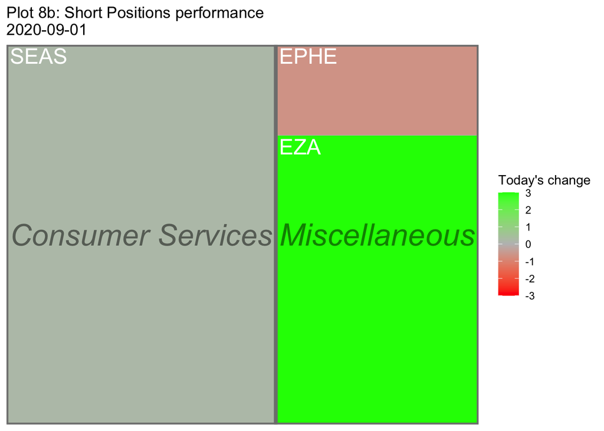

S&P 500 stocks colored by last day performance.

Outliers skew the colors, making the other stocks look pale. I restricted the colors to max of 3 and -3% change. Every stock having higher or lower than 3% change has the same color.

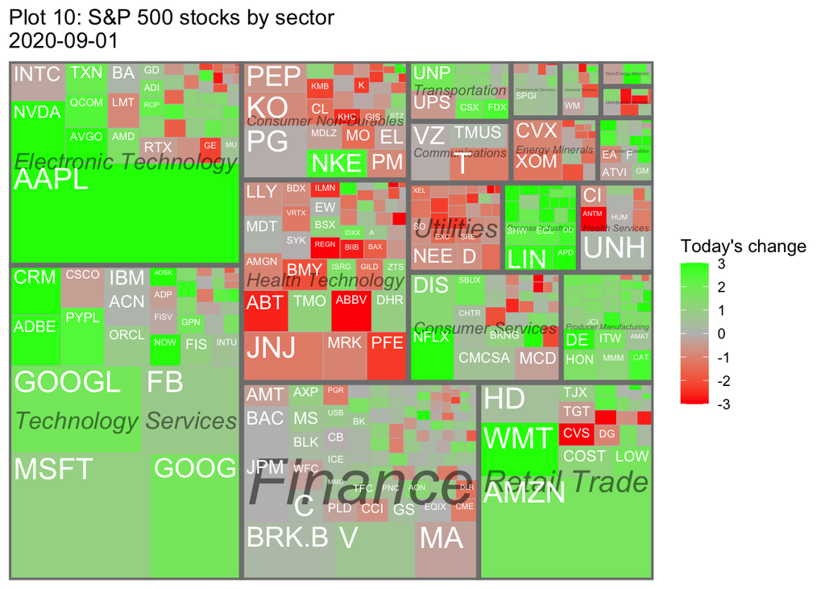

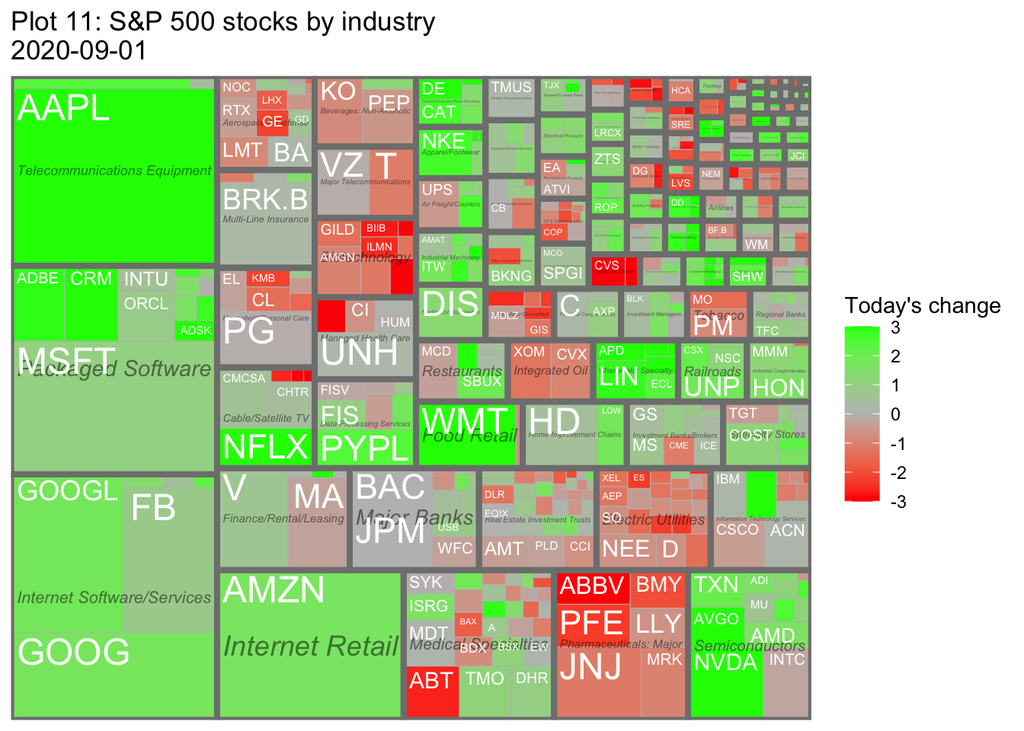